# Linh_Do_Kaggle_Individual_Project_UniversityofUtah

Linh Do - u1537857

Nov 11rd

# Introduction and project goal

In this project, the goal is to develop a parsimonious linear predictive model for house prices in Ames, Iowa, using a dataset split into training and test sets (with 1,460 and 1,459 observations, respectively). Model performance benchmark for minimum estimated out-of-sample R^2 is .75.

The target variable, SalePrice, is provided in the training set but omitted from the test set, challenging us to build a model that generalizes well to unseen data.

In this notebook, I will choose 5 predictors representing different aspects of a property namely MSSubClass, HouseStyle, Neighborhood, OverallQual and SaleType. Below is data description:

More details of the data can be found here: https://www.kaggle.com/c/house-prices-advanced-regression-techniques/data

# Table of Contents

1. Data import
2. Data cleaning and exploration
3. Data modelling
4. Cross-validation
5. Model fitting

## 1. Data import

```r
#load the test and train set
test <- read_csv("/Users/linhdo/Documents/University of Utah/Coursework/Fall 2024/IS 6489 Statistics and Predictive Analytics/Kaggle competition - House price prediction using advanced regression/test.csv")

train <- read_csv("/Users/linhdo/Documents/University of Utah/Coursework/Fall 2024/IS 6489 Statistics and Predictive Analytics/Kaggle competition - House price prediction using advanced regression/train.csv")

head(train)
```

```
## # A tibble: 6 × 81
##      Id MSSubClass MSZoning LotFrontage LotArea Street Alley LotShape
##   <dbl>      <dbl> <chr>          <dbl>   <dbl> <chr>  <chr> <chr>
## 1     1         60 RL                65    8450 Pave   <NA>  Reg
## 2     2         20 RL                80    9600 Pave   <NA>  Reg
## 3     3         60 RL                68   11250 Pave   <NA>  IR1
## 4     4         70 RL                60    9550 Pave   <NA>  IR1
## 5     5         60 RL                84   14260 Pave   <NA>  IR1
## 6     6         50 RL                85   14115 Pave   <NA>  IR1
## # ℹ 73 more variables: LandContour <chr>, Utilities <chr>, LotConfig <chr>,
## #   LandSlope <chr>, Neighborhood <chr>, Condition1 <chr>, Condition2 <chr>,
## #   BldgType <chr>, HouseStyle <chr>, OverallQual <dbl>, OverallCond <dbl>,
## #   YearBuilt <dbl>, YearRemodAdd <dbl>, RoofStyle <chr>, RoofMatl <chr>,
## #   Exterior1st <chr>, Exterior2nd <chr>, MasVnrType <chr>, MasVnrArea <dbl>,
## #   ExterQual <chr>, ExterCond <chr>, Foundation <chr>, BsmtQual <chr>,
## #   BsmtCond <chr>, BsmtExposure <chr>, BsmtFinType1 <chr>, BsmtFinSF1 <dbl>, …
```

```r
head(test)
```

```
## # A tibble: 6 × 80
##      Id MSSubClass MSZoning LotFrontage LotArea Street Alley LotShape
##   <dbl>      <dbl> <chr>          <dbl>   <dbl> <chr>  <chr> <chr>
## 1  1461         20 RH                80   11622 Pave   <NA>  Reg
## 2  1462         20 RL                81   14267 Pave   <NA>  IR1
## 3  1463         60 RL                74   13830 Pave   <NA>  IR1
## 4  1464         60 RL                78    9978 Pave   <NA>  IR1
## 5  1465        120 RL                43    5005 Pave   <NA>  IR1
## 6  1466         60 RL                75   10000 Pave   <NA>  IR1
## # ℹ 72 more variables: LandContour <chr>, Utilities <chr>, LotConfig <chr>,
## #   LandSlope <chr>, Neighborhood <chr>, Condition1 <chr>, Condition2 <chr>,
## #   BldgType <chr>, HouseStyle <chr>, OverallQual <dbl>, OverallCond <dbl>,
## #   YearBuilt <dbl>, YearRemodAdd <dbl>, RoofStyle <chr>, RoofMatl <chr>,
## #   Exterior1st <chr>, Exterior2nd <chr>, MasVnrType <chr>, MasVnrArea <dbl>,
## #   ExterQual <chr>, ExterCond <chr>, Foundation <chr>, BsmtQual <chr>,
## #   BsmtCond <chr>, BsmtExposure <chr>, BsmtFinType1 <chr>, BsmtFinSF1 <dbl>, …
```

Here is the full data of test and train set. After having an overall understanding, we continue to clean and explore the data.

## 2. Data cleaning and exploration

First, we will investigate missing values.

```r
#investigate missing values
count_missings <- function(x) sum(is.na(x))

train |>
  summarize_all(count_missings) # Handy summarize_all function
```

```
## # A tibble: 1 × 81
##      Id MSSubClass MSZoning LotFrontage LotArea Street Alley LotShape
##   <int>      <int>    <int>       <int>   <int>  <int> <int>    <int>
## 1     0          0        0         259       0      0  1369        0
## # ℹ 73 more variables: LandContour <int>, Utilities <int>, LotConfig <int>,
## #   LandSlope <int>, Neighborhood <int>, Condition1 <int>, Condition2 <int>,
## #   BldgType <int>, HouseStyle <int>, OverallQual <int>, OverallCond <int>,
## #   YearBuilt <int>, YearRemodAdd <int>, RoofStyle <int>, RoofMatl <int>,
## #   Exterior1st <int>, Exterior2nd <int>, MasVnrType <int>, MasVnrArea <int>,
## #   ExterQual <int>, ExterCond <int>, Foundation <int>, BsmtQual <int>,
## #   BsmtCond <int>, BsmtExposure <int>, BsmtFinType1 <int>, BsmtFinSF1 <int>, …
```

It can be seen that there is no missing values in 5 choosen predictors in train set.

Second, we will look at the summary of train and test set to discover any potential errors in the data. Now, we only look at our target variables and 5 predictors.

```r
#take a look at the data summary
summary(train[, c("SalePrice", "MSSubClass", "Utilities", "Neighborhood", "OverallQual", "SaleType")])
```

```
##    SalePrice        MSSubClass     Utilities         Neighborhood
##  Min.   : 34900   Min.   : 20.0   Length:1460        Length:1460
##  1st Qu.:129975   1st Qu.: 20.0   Class :character   Class :character
##  Median :163000   Median : 50.0   Mode  :character   Mode  :character
##  Mean   :180921   Mean   : 56.9
##  3rd Qu.:214000   3rd Qu.: 70.0
##  Max.   :755000   Max.   :190.0
##   OverallQual       SaleType
##  Min.   : 1.000   Length:1460
##  1st Qu.: 5.000   Class :character
##  Median : 6.000   Mode  :character
##  Mean   : 6.099
##  3rd Qu.: 7.000
##  Max.   :10.000
```

```r
summary(test[, c("MSSubClass", "Utilities", "Neighborhood", "OverallQual", "SaleType")])
```

```
##    MSSubClass      Utilities         Neighborhood        OverallQual
##  Min.   : 20.00   Length:1459        Length:1459        Min.   : 1.000
##  1st Qu.: 20.00   Class :character   Class :character   1st Qu.: 5.000
##  Median : 50.00   Mode  :character   Mode  :character   Median : 6.000
##  Mean   : 57.38                                         Mean   : 6.079
##  3rd Qu.: 70.00                                         3rd Qu.: 7.000
##  Max.   :190.00                                         Max.   :10.000
##    SaleType
##  Length:1459
##  Class :character
##  Mode  :character
##
##
##
```

According to data dictionary, NA values in these columns do not have any special meaning and indicate missing value. We will replace these missing values with the most frequently occuring value of its field.

```r
# Define mode function
get_mode <- function(x) {
  unique_x <- unique(x)
  unique_x[which.max(tabulate(match(x, unique_x)))]
}

# Replace NA values in MSSubClass with its mode
test$MSSubClass[is.na(test$MSSubClass)] <- get_mode(test$MSSubClass)

# Replace NA values in SaleType with its mode
test$SaleType[is.na(test$SaleType)] <- get_mode(test$SaleType)

# Verify there are no NA values left in these columns
sum(is.na(test$MSSubClass))
```

```
## [1] 0
```

```r
sum(is.na(test$SaleType))
```

```
## [1] 0
```

We finished handling missing values. Now, we will develop parsimonious linear model using 5 predictors additively.

## 3. Data modelling

We will take a look at 2 categorical features: `OverallQual` and `MSSubClass`.

`OverallQual` and `MSSubClass` are categorical features but encoded as numeric. If they are non-linearly related to the target then they should be encoded as factor. If the relationship is linear we will keep them numeric.

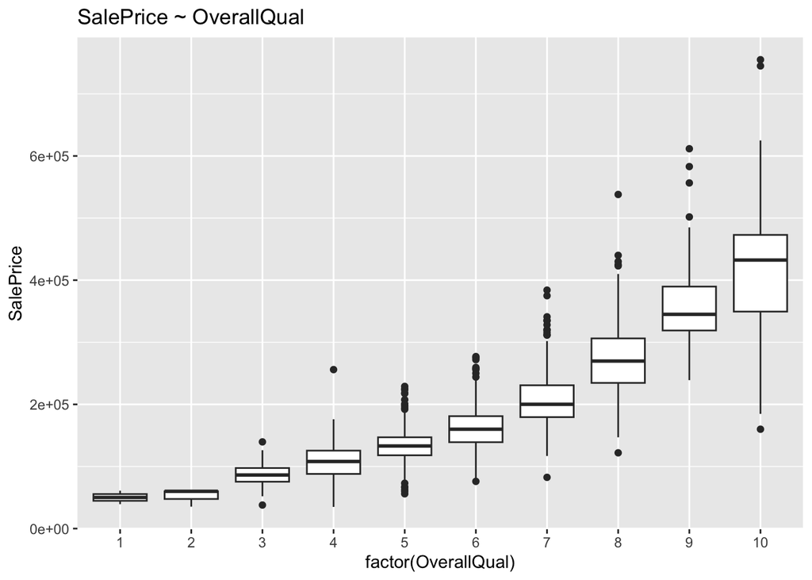

```r
# Check the relationship between SalePrice and OverallQual
train |>
  ggplot(aes(factor(OverallQual), SalePrice)) +
  geom_boxplot() +
  labs(title = "SalePrice ~ OverallQual")
```

This is more of an exponential increase, which is not well described by a line.

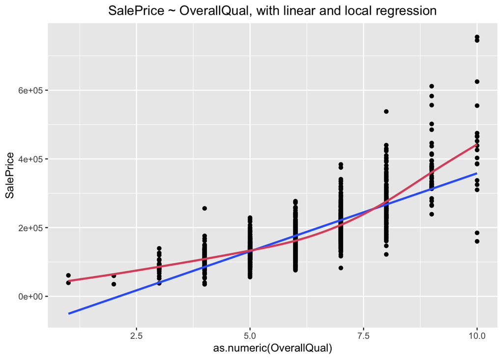

```r
# Plot a regression line vs. a non-linear fit (LOESS)
ggplot(train, aes(as.numeric(OverallQual), SalePrice)) +
  geom_point() +
  geom_smooth(method = "lm", se = F) +
  geom_smooth(se = F, col = 2) + # Local regression named LOESS
  labs(title = "SalePrice ~ OverallQual, with linear and local regression") +
  theme(plot.title = element_text(hjust = 0.5))
```

Better to factor `OverallQual`. We can test that this would be better:

```r
# Compare R-square for the two model specifications

# 1. numeric
lm(SalePrice ~ OverallQual, data = train) |>
  summary() # R-squared: 0.62
```

```
##
## Call:
## lm(formula = SalePrice ~ OverallQual, data = train)
##
## Residuals:
##     Min      1Q  Median      3Q     Max
## -198152  -29409   -1845   21463  396848
##
## Coefficients:
##             Estimate Std. Error t value Pr(>|t|)
## (Intercept) -96206.1     5756.4  -16.71   <2e-16 ***
## OverallQual  45435.8      920.4   49.36   <2e-16 ***
## ---
## Signif. codes:  0 '***' 0.001 '**' 0.01 '*' 0.05 '.' 0.1 ' ' 1
##
## Residual standard error: 48620 on 1458 degrees of freedom
## Multiple R-squared:  0.6257, Adjusted R-squared:  0.6254
## F-statistic:  2437 on 1 and 1458 DF,  p-value: < 2.2e-16
```

```r
# 2. factor
lm(SalePrice ~ factor(OverallQual), data = train) |>
  summary() # R-squared: 0.68
```

```
##
## Call:
## lm(formula = SalePrice ~ factor(OverallQual), data = train)
##
## Residuals:
##     Min      1Q  Median      3Q     Max
## -278588  -24023   -2113   19312  316412
##
## Coefficients:
##                       Estimate Std. Error t value Pr(>|t|)
## (Intercept)              50150      31666   1.584 0.113482
## factor(OverallQual)2      1620      40881   0.040 0.968390
## factor(OverallQual)3     37324      33212   1.124 0.261285
## factor(OverallQual)4     58271      31938   1.824 0.068286 .
## factor(OverallQual)5     83373      31746   2.626 0.008724 **
## factor(OverallQual)6    111453      31751   3.510 0.000461 ***
## factor(OverallQual)7    157566      31766   4.960 7.87e-07 ***
## factor(OverallQual)8    224586      31854   7.050 2.75e-12 ***
## factor(OverallQual)9    317363      32395   9.797  < 2e-16 ***
## factor(OverallQual)10   388438      33380  11.637  < 2e-16 ***
## ---
## Signif. codes:  0 '***' 0.001 '**' 0.01 '*' 0.05 '.' 0.1 ' ' 1
##
## Residual standard error: 44780 on 1450 degrees of freedom
## Multiple R-squared:  0.6842, Adjusted R-squared:  0.6822
## F-statistic:   349 on 9 and 1450 DF,  p-value: < 2.2e-16
```

We could see that the R-squared is higher when we factor OverallQual, indicating that factoring OverallQual fits the data better. Now we will take a look at MSSubClass.

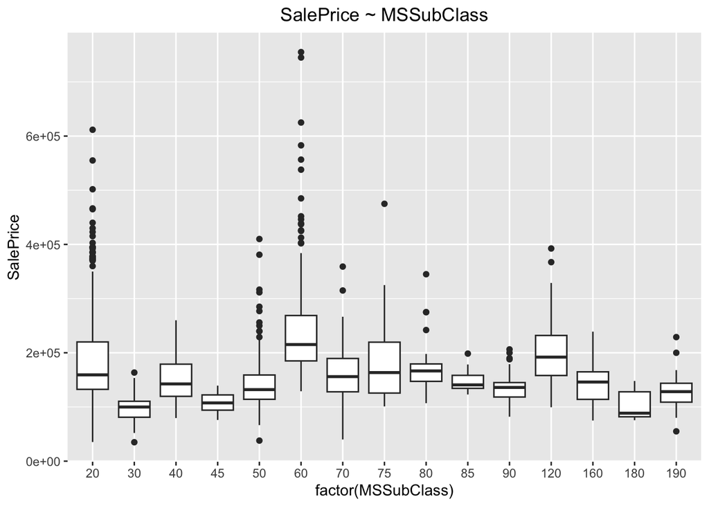

```r
# Check the relationship between SalePrice and MSSubClass.
train |>
  ggplot(aes(factor(MSSubClass), SalePrice)) +
  geom_boxplot() +
  labs(title = "SalePrice ~ MSSubClass") +
  theme(plot.title = element_text(hjust = 0.5))
```

MSSubClass does not seem to have linear relationship with SalePrice. Now we will calculate R-squared for numeric and factor MSSubClass.

```r
# Compare R-square for the two model specifications

# 1. numeric
lm(SalePrice ~ MSSubClass, data = train) |>
  summary() # R-squared: 0.007
```

```
##
## Call:
## lm(formula = SalePrice ~ MSSubClass, data = train)
##
## Residuals:
##     Min      1Q  Median      3Q     Max
## -151451  -51244  -16762   33112  574570
##
## Coefficients:
##              Estimate Std. Error t value Pr(>|t|)
## (Intercept) 189927.44    3474.29   54.67  < 2e-16 ***
## MSSubClass    -158.29      49.01   -3.23  0.00127 **
## ---
## Signif. codes:  0 '***' 0.001 '**' 0.01 '*' 0.05 '.' 0.1 ' ' 1
##
## Residual standard error: 79190 on 1458 degrees of freedom
## Multiple R-squared:  0.007104,   Adjusted R-squared:  0.006423
## F-statistic: 10.43 on 1 and 1458 DF,  p-value: 0.001266
```

```r
# 2. factor
lm(SalePrice ~ factor(MSSubClass), data = train) |>
  summary() # R-squared: 0.25
```

```
##
## Call:
## lm(formula = SalePrice ~ factor(MSSubClass), data = train)
##
## Residuals:
##     Min      1Q  Median      3Q     Max
## -149914  -44225  -12011   23057  515051
##
## Coefficients:
##                       Estimate Std. Error t value Pr(>|t|)
## (Intercept)             185225       2993  61.879  < 2e-16 ***
## factor(MSSubClass)30    -89395       8864 -10.086  < 2e-16 ***
## factor(MSSubClass)40    -29100      34780  -0.837 0.402905
## factor(MSSubClass)45    -76633      20228  -3.788 0.000158 ***
## factor(MSSubClass)50    -41922       6505  -6.445 1.57e-10 ***
## factor(MSSubClass)60     54724       5002  10.940  < 2e-16 ***
## factor(MSSubClass)70    -18452       9434  -1.956 0.050670 .
## factor(MSSubClass)75      7213      17582   0.410 0.681697
## factor(MSSubClass)80    -15488       9579  -1.617 0.106133
## factor(MSSubClass)85    -37415      15783  -2.371 0.017889 *
## factor(MSSubClass)90    -51684      10066  -5.135 3.21e-07 ***
## factor(MSSubClass)120    15554       8010   1.942 0.052354 .
## factor(MSSubClass)160   -46577       9230  -5.046 5.08e-07 ***
## factor(MSSubClass)180   -82925      22118  -3.749 0.000184 ***
## factor(MSSubClass)190   -55612      13002  -4.277 2.02e-05 ***
## ---
## Signif. codes:  0 '***' 0.001 '**' 0.01 '*' 0.05 '.' 0.1 ' ' 1
##
## Residual standard error: 69300 on 1445 degrees of freedom
## Multiple R-squared:  0.2463, Adjusted R-squared:  0.239
## F-statistic: 33.73 on 14 and 1445 DF,  p-value: < 2.2e-16
```

We could see that the R-squared is higher when we factor MSSubClass, indicating that factoring MSSubClass fits the data better. Now, we will factor both OverallQual and MSSubClass.

```r
# factor OverallQual and MSSubClass
train <- train |>
  mutate(
    MSSubClass = factor(MSSubClass),
    OverallQual = factor(OverallQual)
  )
```

## 4. Cross-validation

First, we will divide the training set into two “folds” (train fold and validation fold), with a split ratio of 70/30.

Create an index of random 70% of rows:

```r
# Randomly sample 70% of the rows in an object called index
set.seed(124)
index <- sample(x = 1:nrow(train), size = nrow(train)*.7, replace = F)

# Check
head(index)
```

```
## [1] 1345  167 1002 1435  261  728
```

Use the index to create a random 70/30 split of the data:

```r
# Subset train using index to create a 70% train_fold
train_fold <- train[index, ]

# Subset the remaining rows not included in index to create a 30% validation fold
validation_fold <- train[-index, ]
```

Second, we will fit the model to the train fold and evaluate it on the validation fold. The RMSE and R-squared values on the validation fold will serve as estimates of the model’s performance on unseen data.

```r
# Fit example model
model <- lm(SalePrice ~ MSSubClass + HouseStyle + Neighborhood + OverallQual + SaleType, data = train_fold)

# Get predictions for the validation fold
predictions <- predict(model, newdata = validation_fold)

# Create functions for calculating RMSE and R-squared (necessary for estimating
# out of sample performance)

rmse <- function(observed, predicted) sqrt(mean((observed - predicted)^2))

R2 <- function(observed, predicted){
  TSS <- sum((observed - mean(observed))^2)
  RSS <- sum((observed - predicted)^2)
  1- RSS/TSS
}

# Estimated out of sample RMSE
rmse(validation_fold$SalePrice, predictions)
```

```
## [1] 41372.49
```

```r
# Estimated out of sample R-squared
R2(validation_fold$SalePrice, predictions)
```

```
## [1] 0.7510237
```

This model meets the minimum required benchmark of .75 estimated out of sample R-squared.

Therefore, we wil fit the model using the entire train set and calculate in sample performance

```r
# Fit the model to the entire train set.
submission_model <- lm(SalePrice ~ MSSubClass + HouseStyle + Neighborhood + OverallQual + SaleType, data = train)

# R-squared and RMSE for this model will be the estimated in-sample model performance
summary(submission_model)
```

```
##
## Call:
## lm(formula = SalePrice ~ MSSubClass + HouseStyle + Neighborhood +
##     OverallQual + SaleType, data = train)
##
## Residuals:
##     Min      1Q  Median      3Q     Max
## -242198  -19694   -1955   15747  275067
##
## Coefficients:
##                     Estimate Std. Error t value Pr(>|t|)
## (Intercept)          98611.0    31846.4   3.096 0.001997 **
## MSSubClass30        -27785.7     6023.2  -4.613 4.33e-06 ***
## MSSubClass40         -9387.1    19079.6  -0.492 0.622798
## MSSubClass45        -32183.6    29534.5  -1.090 0.276035
## MSSubClass50        -15953.9    12494.0  -1.277 0.201838
## MSSubClass60          4747.2    10683.7   0.444 0.656868
## MSSubClass70        -19083.3    11566.5  -1.650 0.099193 .
## MSSubClass75          5141.3    20849.9   0.247 0.805263
## MSSubClass80          -145.2    17559.5  -0.008 0.993405
## MSSubClass85          3060.6    15249.5   0.201 0.840962
## MSSubClass90         -8363.7     6757.1  -1.238 0.216012
## MSSubClass120       -36048.1     5323.5  -6.771 1.87e-11 ***
## MSSubClass160       -49007.1    12511.7  -3.917 9.40e-05 ***
## MSSubClass180       -28332.9    18644.6  -1.520 0.128830
## MSSubClass190        -9884.9    10536.1  -0.938 0.348309
## HouseStyle1.5Unf    -18504.8    28826.7  -0.642 0.521021
## HouseStyle1Story    -10026.9    11956.7  -0.839 0.401837
## HouseStyle2.5Fin     25078.5    22091.6   1.135 0.256482
## HouseStyle2.5Unf    -32358.6    21534.1  -1.503 0.133151
## HouseStyle2Story      -791.4    11393.7  -0.069 0.944635
## HouseStyleSFoyer    -17995.3    15714.7  -1.145 0.252353
## HouseStyleSLvl       -9611.6    18837.6  -0.510 0.609968
## NeighborhoodBlueste  -4091.7    29479.1  -0.139 0.889629
## NeighborhoodBrDale  -33867.1    15583.0  -2.173 0.029923 *
## NeighborhoodBrkSide -28535.9    12424.9  -2.297 0.021785 *
## NeighborhoodClearCr  27538.8    12710.5   2.167 0.030433 *
## NeighborhoodCollgCr -16594.4    10733.0  -1.546 0.122302
## NeighborhoodCrawfor  22245.1    12109.6   1.837 0.066424 .
## NeighborhoodEdwards -37442.7    11484.1  -3.260 0.001139 **
```

[output cut: 25 more lines]

```
## OverallQual10       306170.9    28522.3  10.734  < 2e-16 ***
## SaleTypeCon          44545.4    28003.4   1.591 0.111900
## SaleTypeConLD        10802.6    14441.7   0.748 0.454576
## SaleTypeConLI         6786.8    18018.7   0.377 0.706489
## SaleTypeConLw         2874.4    18717.3   0.154 0.877973
## SaleTypeCWD          13852.6    19927.0   0.695 0.487065
## SaleTypeNew          30903.1     7213.8   4.284 1.96e-05 ***
## SaleTypeOth           3902.2    22682.1   0.172 0.863433
## SaleTypeWD            8448.0     5995.5   1.409 0.159042
## ---
## Signif. codes:  0 '***' 0.001 '**' 0.01 '*' 0.05 '.' 0.1 ' ' 1
##
## Residual standard error: 37510 on 1397 degrees of freedom
## Multiple R-squared:  0.7866, Adjusted R-squared:  0.7771
## F-statistic: 83.04 on 62 and 1397 DF,  p-value: < 2.2e-16
```

- In sample R-squared: 0.7866
- In sample RMSE (residual standard error): 37510 This is average error (in dollars) made by the model.

## 5. Model fitting

Now, we will factor MSSubClass and OverallQual in test set as we did in train set.

```r
# Copy changes made to train in Test
test <- test |>
  mutate(
    MSSubClass = factor(MSSubClass),
    OverallQual = factor(OverallQual)
  )
```

Now we will use the model to predict the missing SalePrice in the test set. There is a new level 150 for MSSubClass. Therefore, we will align factor levels between train and test data.

```r
# Ensure both training and test sets have the same factor levels
train$MSSubClass <- factor(train$MSSubClass)
test$MSSubClass <- factor(test$MSSubClass, levels = levels(train$MSSubClass))

# Make predictions
submission_predictions <- predict(submission_model, newdata = test)
head(submission_predictions)
```

```
##        1        2        3        4        5        6
## 138252.5 158728.7 154033.4 174509.6 266769.1 174509.6
```

Finally, I will format my submission file.

```r
submission <- test |>
  select(Id) |>
  mutate(SalePrice = submission_predictions)

# Check
head(submission)
```

```
## # A tibble: 6 × 2
##      Id SalePrice
##   <dbl>     <dbl>
## 1  1461   138253.
## 2  1462   158729.
## 3  1463   154033.
## 4  1464   174510.
## 5  1465   266769.
## 6  1466   174510.
```

```r
# write to csv
write.csv(submission, "kaggle_submission_linh_do_final.csv", row.names = F)
```

The Kaggle score is 0.19501 and this workbook ranked 4439.